# Pristina TranscriptomicLandscape 03: Weighted Gene Coexpression Network Analysis

Alberto Perez-Posada @apposada

1/12/2022

## About

This markdown showcases the use of WGCNA (Langfelder & Horvath, 2008) to identify modules of genes that are regulated in a similar manner across clusters of cell types, using pseudo-bulk data from gene counts aggregated at the Leiden cluster level. In this particular case, the clusters correspond to specific cell types validated using in situ hybridisations of cell markers.

This markdown contains the main code chunks necessary for data transformation and running of WGCNA. For more information and a more detailed documentation, please refer to this script from the original documentation: https://horvath.genetics.ucla.edu/html/CoexpressionNetwork/Rpackages/WGCNA/Tutorials/Consensus-NetworkConstruction-man.R

## Loading Necessary Packages

```r
library(data.table)
library(reshape2)
library(dplyr)
library(tidyverse)
library(ComplexHeatmap)
library(ggplot2)
library(circlize)
library(RColorBrewer)
library(viridis)
library(colorspace)
library(WGCNA)
```

## Loading necessary code (CHANGE PATHS)

```r
source("./code/R_functions/wgcna_igraph_functions/wgcna_igraph_functions.R")
```

## Data Preparation

We prepare by loading the necessary data from our previous markdowns:

```r
load(
  "./outputs/rda/02_tf_analysis.rda"
)
```

We load our table of plei counts as input for the wgcna analysis.

```r
input_wgcna <-
  plei_cpm[,1:49]
```

We will select variable genes to enter the analysis of WGCNA, with a CV > 1. Gene expression data will also be scaled by centering around the mean (z-score). datExpr is the data frame in the format that WGCNA likes.

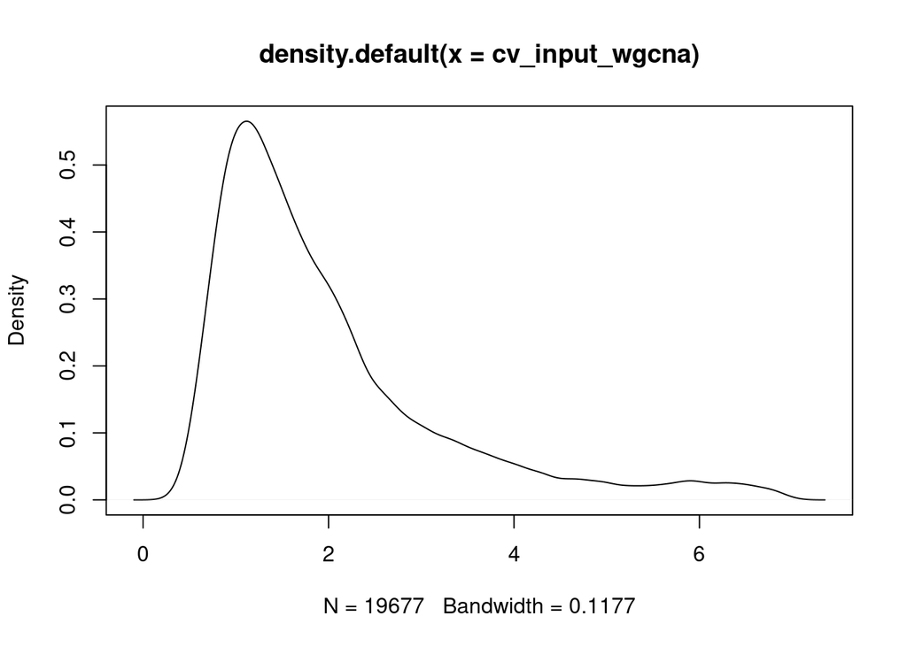

```r
# Filter of high CV
cv_input_wgcna <-
  apply(input_wgcna, 1, function(x)
    sd(x) / mean(x))
cv_input_wgcna <- cv_input_wgcna[complete.cases(cv_input_wgcna)]
plot(density(cv_input_wgcna))
```

```r
cv_input_wgcna <-
  cv_input_wgcna[cv_input_wgcna > 1]

# Defining the datExpr object
datExpr = as.data.frame(
  scale(
    t(
      input_wgcna[
        rownames(input_wgcna) %in% names(cv_input_wgcna),
        ]
      )
    )
  ) # perhaps I should not scale them.

rownames(datExpr) <- colnames(plei_cpm)
nGenes <- ncol(datExpr)
nSamples <- nrow(datExpr)
```

WGCNA normally makes sanity checks of sample composition and similarity, using hierarchical clustering of samples to detect and remove outliers. We will leave all our cell clusters, but here is the tree of clustering anyways.

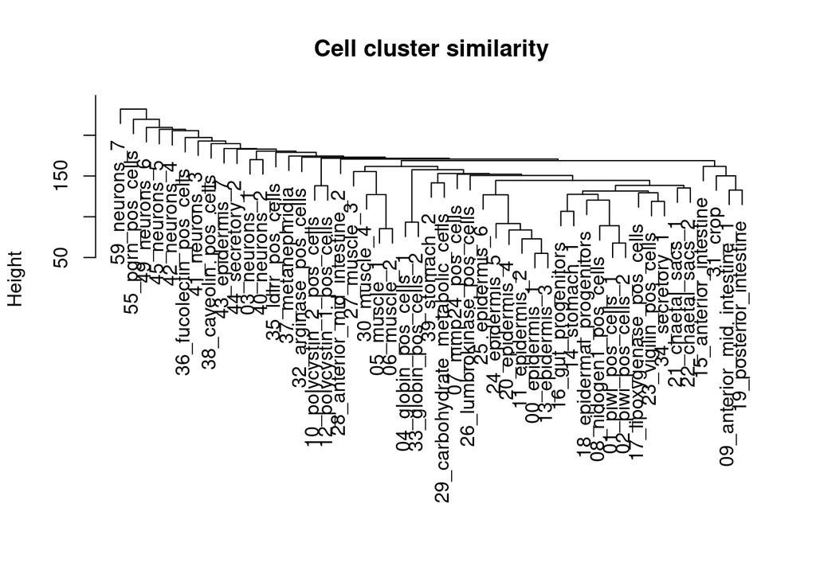

```r
sampleTree <- hclust(dist(datExpr), method = "average")

plot(
  sampleTree,
  main = "Cell cluster similarity",
  sub = "",
  xlab = ""
)
```

### Power estimation

We generate a set of numbers to run the analysis of scale free topology.

```r
# Choose a set of soft-thresholding powers
powers <- c(c(1:10), seq(from = 12, to = 20, by = 2))
powers
```

```
##  [1]  1  2  3  4  5  6  7  8  9 10 12 14 16 18 20
```

We proceed to run the analysis of scale free topology for multiple soft thresholding powers. The aim is to help the user pick an appropriate soft-thresholding power for network construction.

```r
# Call the network topology analysis function
sft <- pickSoftThreshold(datExpr, powerVector = powers, verbose = 5)
```

```
## pickSoftThreshold: will use block size 2793.
##  pickSoftThreshold: calculating connectivity for given powers...
##    ..working on genes 1 through 2793 of 16015
```

```
##    ..working on genes 2794 through 5586 of 16015
##    ..working on genes 5587 through 8379 of 16015
##    ..working on genes 8380 through 11172 of 16015
##    ..working on genes 11173 through 13965 of 16015
##    ..working on genes 13966 through 16015 of 16015
##    Power  SFT.R.sq   slope truncated.R.sq mean.k. median.k. max.k.
## 1      1 0.0364000 -0.8790          0.829  2040.0  2050.000   3180
## 2      2 0.0000665  0.0167          0.970   527.0   496.000   1040
## 3      3 0.4410000 -1.2200          0.812   229.0   192.000    678
## 4      4 0.9040000 -1.5100          0.955   134.0   102.000    537
## 5      5 0.9370000 -1.5500          0.981    92.1    63.000    483
## 6      6 0.9420000 -1.5500          0.984    68.7    40.800    440
## 7      7 0.9400000 -1.5400          0.987    54.1    27.300    405
## 8      8 0.9370000 -1.5300          0.988    44.2    19.000    375
## 9      9 0.9300000 -1.5200          0.982    37.1    13.400    349
## 10    10 0.9250000 -1.5200          0.984    31.7     9.690    327
## 11    12 0.9110000 -1.5000          0.979    24.4     5.340    289
## 12    14 0.9120000 -1.4700          0.990    19.6     3.040    258
## 13    16 0.8900000 -1.4600          0.961    16.3     1.820    233
## 14    18 0.8950000 -1.4300          0.960    13.9     1.120    212
## 15    20 0.8780000 -1.4200          0.932    12.1     0.713    194
```

```r
sft
```

```
## $powerEstimate
## [1] 4
##
## $fitIndices
##    Power      SFT.R.sq      slope truncated.R.sq    mean.k.    median.k.
## 1      1 0.03636296952 -0.8785503      0.8285614 2035.60218 2047.5663219
## 2      2 0.00006647954  0.0167356      0.9704216  526.84439  496.4953726
## 3      3 0.44089090926 -1.2155865      0.8123787  229.05296  191.5096219
## 4      4 0.90420076016 -1.5100473      0.9545203  134.44456  102.2037773
## 5      5 0.93694271986 -1.5475249      0.9808118   92.10527   62.9997661
## 6      6 0.94163983769 -1.5525737      0.9838674   68.72968   40.7805012
## 7      7 0.94009826465 -1.5391256      0.9865323   54.09938   27.2704672
## 8      8 0.93704939284 -1.5338985      0.9878146   44.17799   19.0381248
## 9      9 0.92960346942 -1.5241600      0.9824874   37.06455   13.4273023
## 10    10 0.92465116836 -1.5195010      0.9839415   31.74974    9.6914316
```

[output cut: 21 more lines]

Browsing the fitting of the topology model we can pick our Beta soft thresholding power of choice (Beta = 5 in this case), as it provides a high R^2 fit and it also lays at the turning point between a lot of connectivity and very low connectivity.

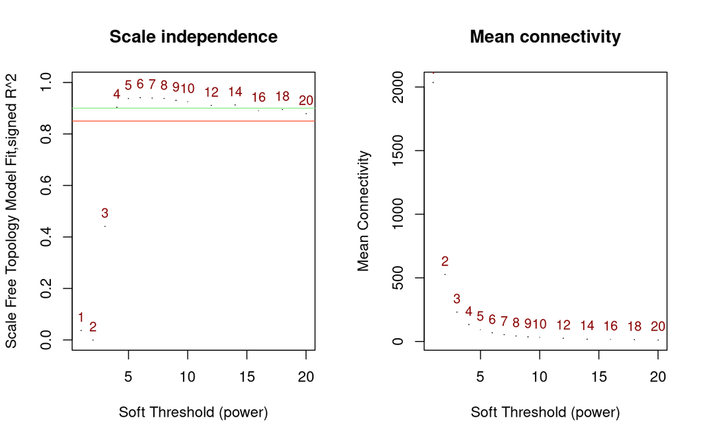

```r
softPower  <-  5
```

## The Adjacency Matrix

WGCNA’s criterion, for two genes to be adjacent, is that they show similar levels of co-regulation. Co-regulation is defined high values of signed Pearson Correlation (that is, they show high levels of correlation or anti-correlation).

The output is a matrix of n genes x n genes showcasing the level of corregulation between genes.

```r
adjacency  <-  adjacency(
  datExpr,
  power = softPower
  )
dim(adjacency)
```

```
## [1] 16015 16015
```

## The Topological Overlapped Matrix (TOM)

But WGCNA does not leave it there. This method takes into account the amount of shared neighbourhoods between pairs of genes to strengthen or weaken the level of association between the two.

As before, the TOM matrix is a n genes x n genes matrix.

```r
TOM <- TOMsimilarity(adjacency)
```

```
## ..connectivity..
## ..matrix multiplication (system BLAS)..
## ..normalization..
## ..done.
```

```r
rownames(TOM) <- rownames(adjacency)
colnames(TOM) <- colnames(adjacency)
dim(TOM)
```

```
## [1] 16015 16015
```

```r
# load("./data/05_wgcnadata/20221201_tom.rda")
# rownames(TOM) <- rownames(adjacency)
# colnames(TOM) <- colnames(adjacency)
# dim(TOM)
```

The TOM can be used to generate graph objects that can be analysed using igraph. We will do that later.

Higher values of TOM indicate higher level of association. This metric can be transformed to depict (dis)similarity between the genes, which gets us closer to the clustering steps.

```r
dissTOM <- 1 - TOM
```

## Clustering and module detection

WGCNA uses hierarchical clustering of the TOM-derived similarity to determine module membership.

```r
geneTree = hclust(as.dist(dissTOM), method = "average")
```

We set a minimum module size of a hundred genes, and ask to cut the tree. See `?cutreeDynamic` for a larger explanation.

Importantly: The output value is a vector of numerical labels giving assignment of objects to modules. Unassigned objects are labeled 0, the largest module has label 1, next largest 2 etc.

```r
minModuleSize <- 100

dynamicMods <- cutreeDynamic(
  dendro = geneTree,
  distM = dissTOM,
  deepSplit = 1,
  pamRespectsDendro = FALSE,
  minClusterSize = minModuleSize
)
```

```
##  ..cutHeight not given, setting it to 0.993  ===>  99% of the (truncated) height range in dendro.
##  ..done.
```

The output vector, can be transformed from discrete numeric values to colors for a more qualitative, but equally blindfolded naming system. Because the order of the contents of the vector matches the order of the genes in the datExpr matrix and the TOM matrix, we can transfer the gene names to this vector to retrieve an association gene-module.

```r
moduleColors <- labels2colors(dynamicMods)
names(moduleColors) <- colnames(datExpr)
```

And even more, we can transform this information in a more human-friendly (and dplyr-friendly) format that we will use extensively in our downstream analysis:

```r
plei_id_module_wgcna <- data.frame(
  id = colnames(datExpr),
  module = moduleColors
)

head(plei_id_module_wgcna)
```

```
##                                  id    module
## PrileiEVm000002t1 PrileiEVm000002t1    purple
## PrileiEVm000003t1 PrileiEVm000003t1    yellow
## PrileiEVm000004t1 PrileiEVm000004t1 turquoise
## PrileiEVm000005t1 PrileiEVm000005t1       tan
## PrileiEVm000006t1 PrileiEVm000006t1   skyblue
## PrileiEVm000008t1 PrileiEVm000008t1 lightcyan
```

We can visualise the looks of our modules with `plotDendroAndColors`.

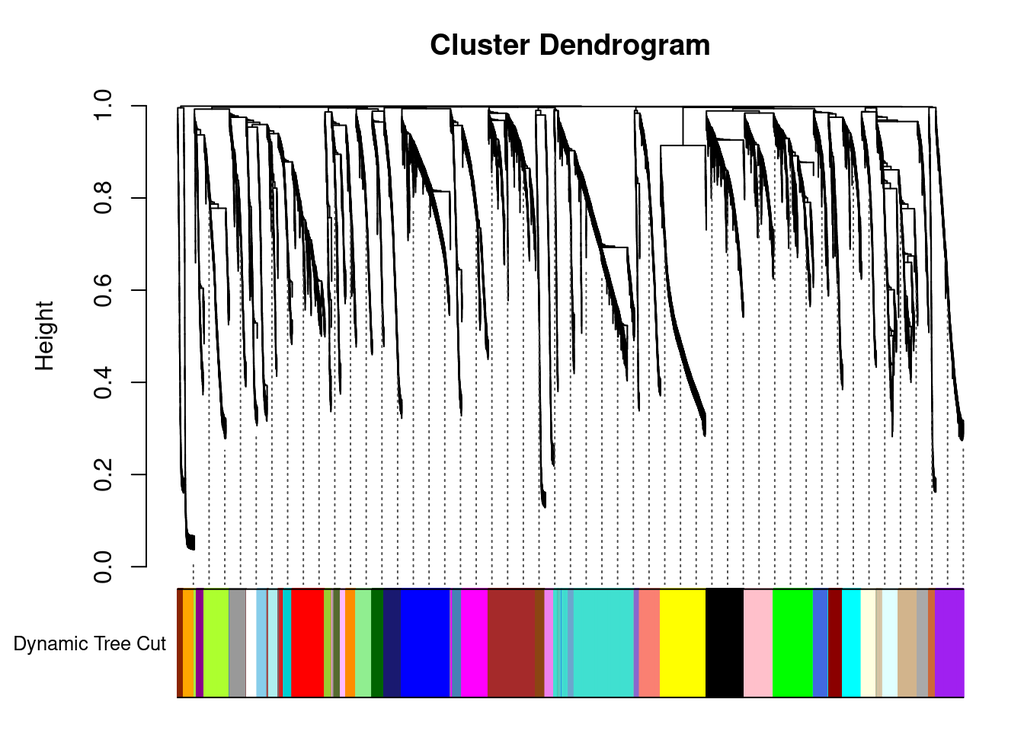

```r
plotDendroAndColors(
  geneTree,
  moduleColors,
  c("Dynamic Tree Cut"),
  dendroLabels = FALSE,
  hang = 0.03,
  addGuide = TRUE,
  guideHang = 0.05
)
```

Based on the early splitting and length of branches, from this plot we can observe that gene modules are defined very discretely. We were able to observe a similar trend when browsing the heatmaps of the transcription factors in markdown #02.

This can change for every dataset based on the species, quality of the data, and overall conditions of the experiment.

WGCNA allows for extra steps to merge together modules that are too similar that were perhaps accidentally split when cutting the tree. This was not done for Pristina as gene modules provided to be very modular.

As said before, refer to the official documentation for a more detailed depiction of the step-by-step-analysis.

## Plotting the network

```r
#' Plot the network
restGenes <- (moduleColors != "grey")
diss1 <- 1-TOMsimilarityFromExpr( datExpr[, restGenes], power = softPower )
```

```
## TOM calculation: adjacency..
## ..will not use multithreading.
##  Fraction of slow calculations: 0.000000
## ..connectivity..
## ..matrix multiplication (system BLAS)..
## ..normalization..
## ..done.
```

```r
hier1 <- hclust(as.dist(diss1), method="average" )
diag(diss1) = NA

png(
  file = "./data/05_wgcnadata/wgcna_NetworkTOMplot.png",
  width = 1280,
  height = 1280,
  units = "px",
  res = 300
)
TOMplot(1-diss1^4, hier1, as.character(moduleColors[restGenes]), # 1-X to change color
        main = "TOM heatmap plot, module genes" )
dev.off()
```

And the ouptut:

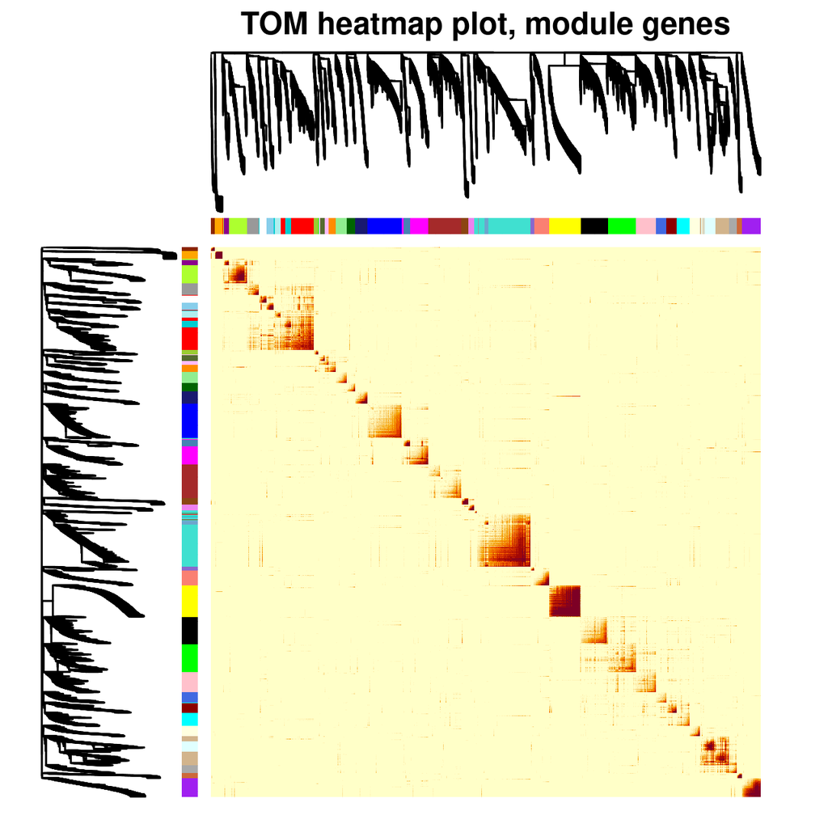

TOM plot of Pristina leidyi genes

## Eigengenes

From the definition in the original paper, the eigengene of a given module can be understood as: “The first principal component of a given module. It can be considereded a representative of the expression profiles of the genes in taht given module.” (slightly adapted for clarity)

```r
# Calculate eigengenes
MEList <- moduleEigengenes(datExpr, colors = moduleColors)
MEs <- MEList$eigengenes

# Cluster module eigengenes
METree <- hclust(
  as.dist(1 - cor(MEs)), # Calculate dissimilarity of module eigengenes
  method = "average"
  )
```

We transform the eigengene table in a more human-friendly format

```r
plei_eigengenes <- data.frame(t(MEs))
rownames(plei_eigengenes) <- sub("ME", "", rownames(plei_eigengenes))

head(plei_eigengenes[,1:5])
```

```
##           X01_piwi_pos_cells_1 X02_piwi_pos_cells_2 X08_nidogen1_pos_cells
## black              0.006094824        -0.0004914248            -0.01371629
## blue              -0.000080402        -0.0029006890            -0.02505595
## brown              0.608484786         0.3751581737             0.30889865
## cyan               0.065233173         0.0430646876             0.02916095
## darkgreen          0.023239103         0.0167503455             0.01184762
## darkgrey           0.006919231        -0.0013238905             0.02478419
##           X18_epidermal_progenitors X00_epidermis_1
## black                  -0.014402560    -0.022905702
## blue                   -0.007776522     0.002004687
## brown                   0.122313534     0.033378997
## cyan                   -0.001442950    -0.009169913
## darkgreen               0.070128057    -0.008415745
## darkgrey               -0.002543282    -0.012260286
```

To plot the looks of the eigengenes and how they relate to each other:

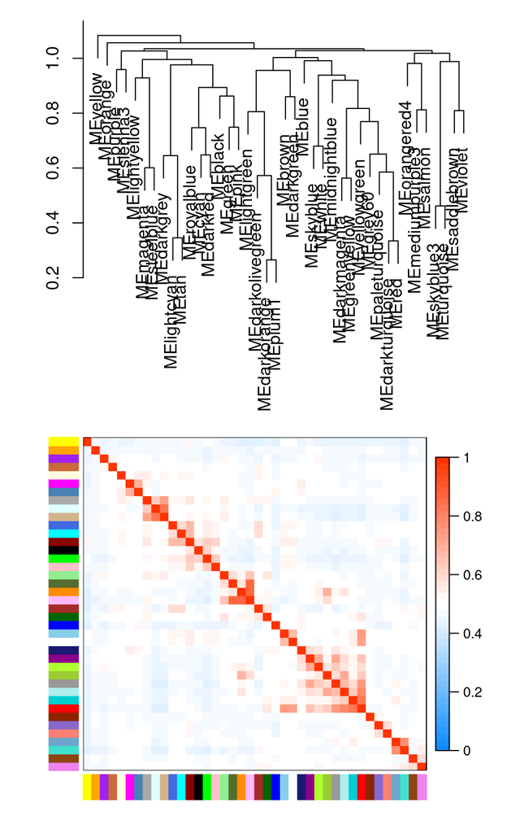

```r
plotEigengeneNetworks(
  orderMEs(MEs),
  "",
  marDendro = c(0, 4, 1, 2),
  marHeatmap = c(3, 4, 1, 2),
  cex.lab = 0.8,
  xLabelsAngle = 90
)
```

## Module membership and connectivity.

For each gene, WGCNA defines a “fuzzy” measure of module membership by correlating the expression profile to that of the module eigengenes. If this value is closer to 1 it indicates that that gene is connected to many genes of that module.

```r
datKME <- signedKME(datExpr, MEs, outputColumnName = "MM_")
```

We can use this data object to retrieve the top connected genes within each module. This can be used as an alternative entry point for the generation of graphs of highly-connected genes. (Currently unused in the manuscript).

```r
plei_id_module_kME <-
  id_module_kME(
    modulecolors = moduleColors,
    datkme = datKME
  )

filt_kME <- plei_id_module_kME$kME > 0.9

plei_top_connected <-
  plei_id_module_kME[filt_kME,1:2] #two first columns

# This below works because adjacency, TOM and dissTOM are in the same order
# dissTOM_top_connected <-
#   dissTOM[
#     rownames(adjacency) %in% plei_top_connected$id,
#     colnames(adjacency) %in% plei_top_connected$id
#     ]
```

We will revisit this a bit differently in the graph analysis (see markdown #04).

## Curating the module membership information

We have included a(n even more) human-friendly naming system for the gene modules of Pristina. This is based on the cell type where the respective eigengene is more highly expressed, and/or a prominent biological process of relevance enriched in the functional annotation of the genes comprising that module (i.e. cilia module).

New colors were “chosen” based on the cell type where they are most highly expressed. To prevent confunsion with the color palette of the cell clusters, we used more vibrant colors in agreement with WGCNA vibrant colors added by default.

```r
plei_modules_table <-
  read.delim2(
    "./data/05_wgcnadata/plei_modules_table.tsv",
    header = T,
    stringsAsFactors = F,
  )

plei_id_module_newname <-
  merge(
    x = plei_id_module_wgcna,
    y = plei_modules_table[,c(1,3,5)],
    by.x = 2,
    by.y = 1,
    all.x = TRUE
  )[,c(2,3,4)]

head(plei_modules_table)
```

```
##    wgcna_module   wgcna_color                     newname newcolor
## 1         brown         brown         01_piwi_pos_cells_1  #585858
## 2     turquoise     turquoise              11_epidermis_2  #93C5FB
## 3      skyblue3      skyblue3              25_epidermis_6  #1E90FF
## 4 paleturquoise paleturquoise                     31_crop  #074722
## 5   greenyellow   greenyellow       15_anterior_intestine  #228B22
## 6   darkmagenta   darkmagenta 09_anterior_mid_intestine_1  #32CD32
##             module_humanfriendly
## 1                    module_piwi
## 2              module_epidermis2
## 3              module_epidermis6
## 4                    module_crop
## 5      module_anterior_intestine
## 6 module_anterior_mid_intestine1
```

```r
head(plei_id_module_newname)
```

```
##                  id      newname module_humanfriendly
## 1 PrileiEVm018902t1 49_neurons_6      module_neurons6
## 2 PrileiEVm014573t1 49_neurons_6      module_neurons6
## 3 PrileiEVm018500t1 49_neurons_6      module_neurons6
## 4 PrileiEVm021538t1 49_neurons_6      module_neurons6
## 5 PrileiEVm007606t1 49_neurons_6      module_neurons6
## 6 PrileiEVm003988t1 49_neurons_6      module_neurons6
```

From now on we will use the ‘curated’ module names, but we will keep the original ones in our environment as well.

One additional note: we will prune the module assignment by removing genes that have very very low counts in their assigned modules. This conservative decision will prevent over-fitting and potential artefactual results.

[output not shown]

We will store a second TOM, pruned in such a way, to generate graphs in the upcoming analyses.

```r
TOM_2 <- TOM[
  rownames(TOM) %in% plei_id_module$id,
  colnames(TOM) %in% plei_id_module$id
]
```

Here is the expression throughout all cell clusters for each module eigengene, using the colors and naming of the new table:

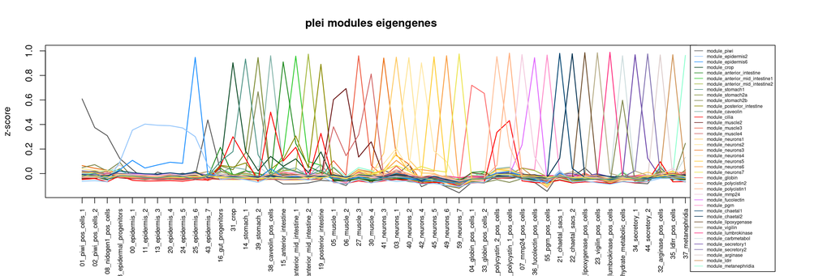

A tidier version of our expression data, organised by module membership:

```r
plei_wg_viz <- merge(
  t(datExpr),
  plei_id_module,
  by.x = 0,
  by.y = 1,
  all.y = T # do we need this here?
  ) %>%
  column_to_rownames("Row.names") %>%
  arrange(module)
```

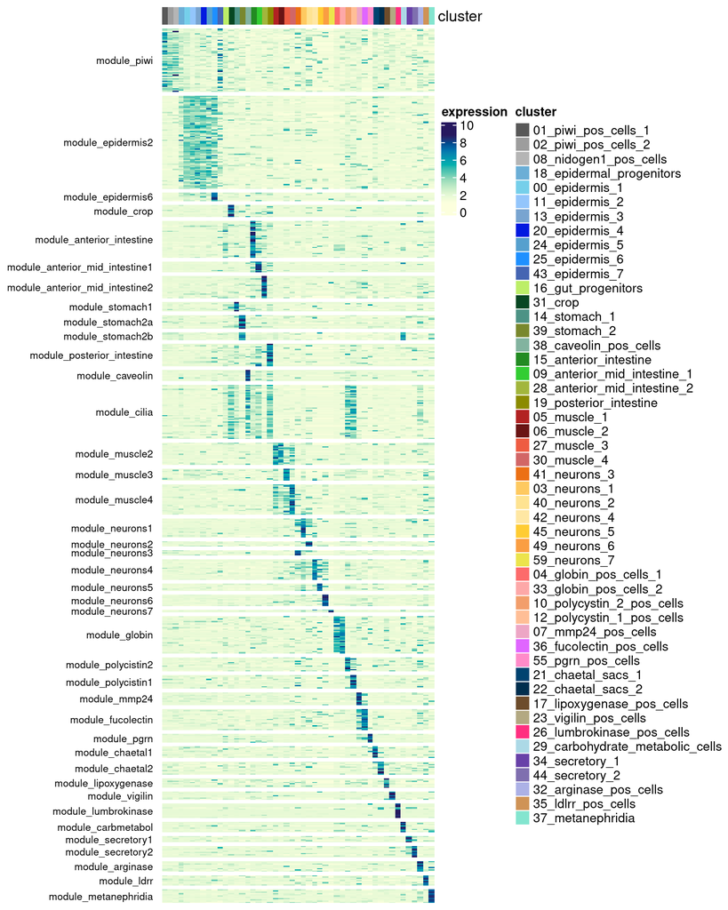

```r
# Fisher test TFs in modules / TFs in the whole genome
nrow(plei_id_module[plei_id_module$id %in% rownames(plei_tfs_cpm),])
```

```
## [1] 271
```

## Connectivity of transcription factor classes and module eigengenes

```r
plei_modules <- plei_modules_table$newname
plei_modules_colors <- plei_modules_table$newcolor
```

We subset the datKME table (correlation genes - eigengenes) to retrieve the transcription factors.

```r
plei_tfs_modules_cor <- datKME[
  rownames(datKME) %in% rownames(plei_tfs_cpm_topclass),
]

plei_tfs_modules_cor <-
  plei_tfs_modules_cor[
    ,
    match(
      plei_modules_table$wgcna_module,
      sub( "MM_","",colnames(datKME) )
      )
    ]

colnames(plei_tfs_modules_cor) <- plei_modules
```

We will count the number of TFs of each class that show high connectivity to each module and will use this as a proxy to infer what TF classes are potentially regulating each gene module.

```r
plei_tfs_modules <-
  matrix(
    0,
    nrow = length(plei_tfs_mainclasses),
    ncol = length(plei_modules)
    )

rownames(plei_tfs_modules) <-
  plei_tfs_mainclasses

colnames(plei_tfs_modules) <-
  plei_modules

plei_tfs_modules_pct <- plei_tfs_modules
```

Fill the matrices:

```r
for (i in plei_modules) {
  h <- which(plei_modules == i)
  for (j in plei_tfs_mainclasses) {
    n <- which(plei_tfs_mainclasses == j)
    all_tfs_class_j <- plei_tfs$id[plei_tfs$class == j]

    cors_jclass_in_imodule <-
      plei_tfs_modules_cor[
        rownames(plei_tfs_modules_cor) %in% all_tfs_class_j,
        colnames(plei_tfs_modules_cor) == i
        ]

    good_tfs_jclass_in_imodule <-
      length(
        cors_jclass_in_imodule[cors_jclass_in_imodule > 0.5] # play around with this: % of TFs in that class with cor > 0.5,0.6, ...
        )

    plei_tfs_modules[n, h] <-
      good_tfs_jclass_in_imodule

    plei_tfs_modules_pct[n, h] <-
      good_tfs_jclass_in_imodule / length(cors_jclass_in_imodule) #maybe the way to do this is by dividing by the total number of TFs expressed in that module... except this is not a cell type or a physical location...
  }
}
```

Some heatmaps for visual representation of the pct of genes in each TF class that highly correlate with eigengenes.

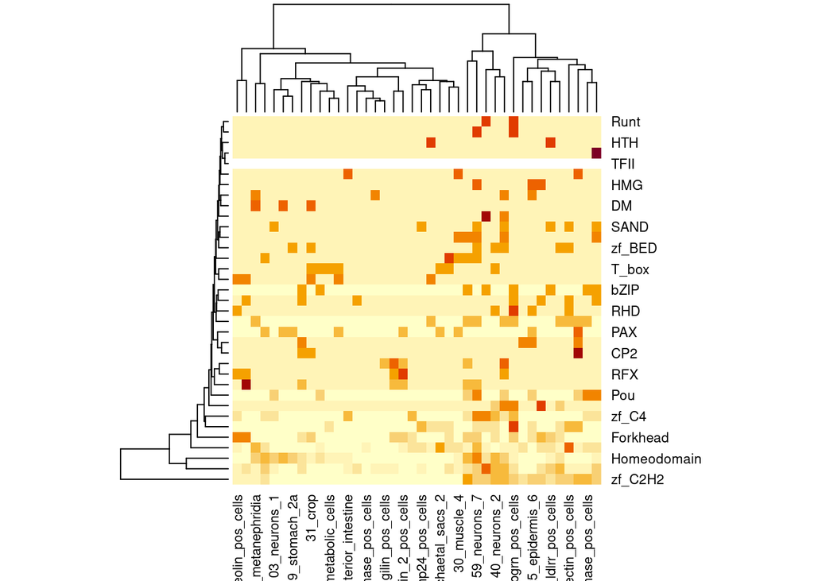

```r
heatmap(plei_tfs_modules)
```

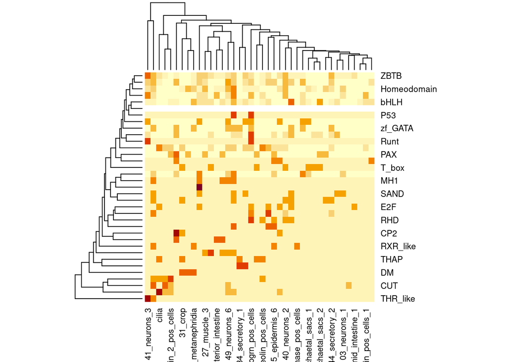

```r
heatmap(plei_tfs_modules_pct)
```

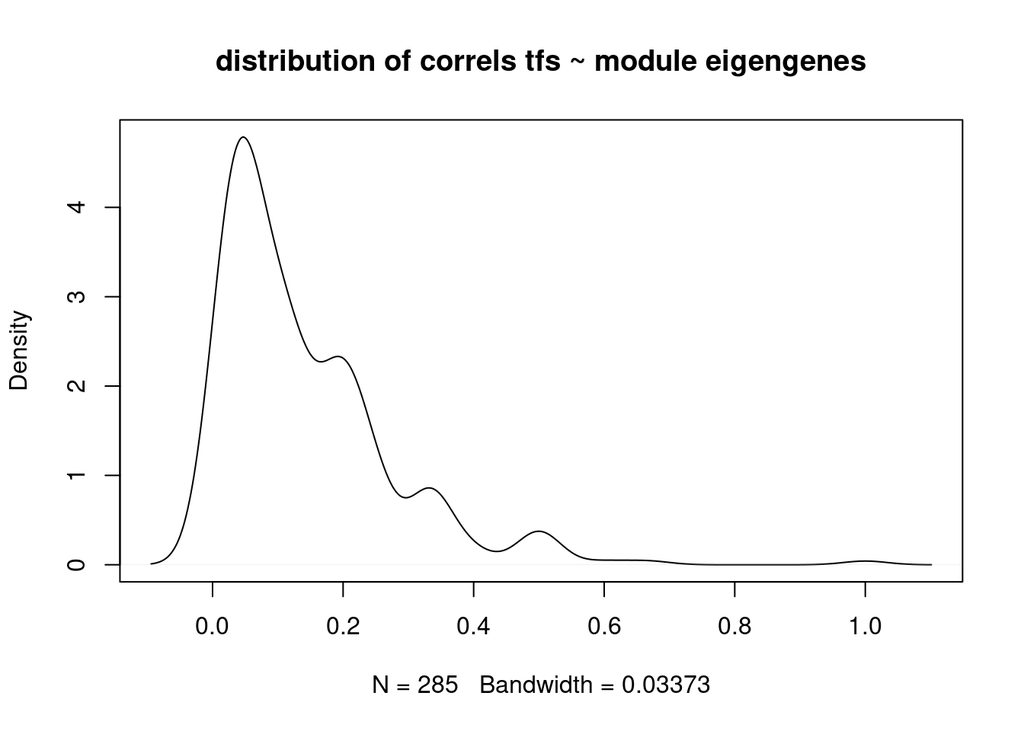

```r
plot(
  density(
    plei_tfs_modules_pct[
      plei_tfs_modules_pct > 0
      ]
    ),
  main = "distribution of correls tfs ~ module eigengenes"
  )
```

A tidier visualisation:

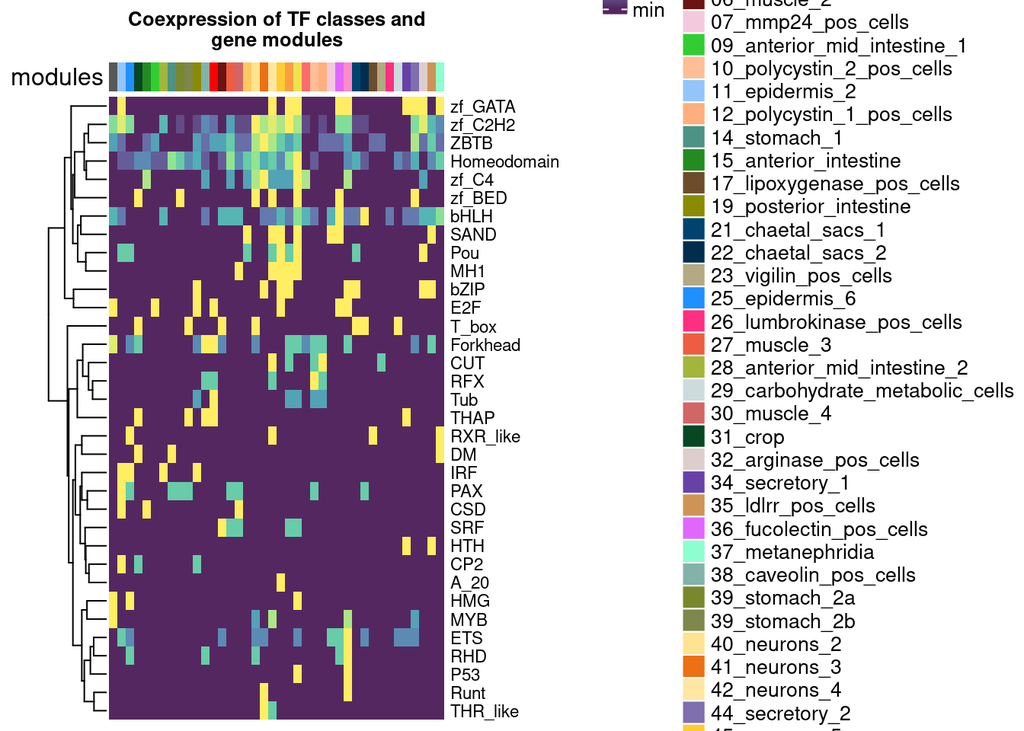

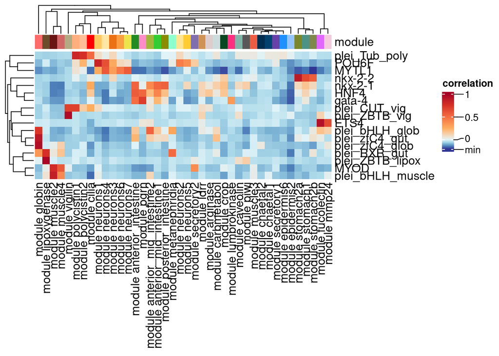

```r
plei_specific_tfs <- read.delim2(
  "./data/03_TFdata/plei_specific_tfs.tsv",
  header = T
)

tf_eigen <-
  datKME[
    rownames(datKME) %in% plei_specific_tfs$id,
  ]

rownames(tf_eigen) <-
  plei_specific_tfs$TF[
    match(rownames(tf_eigen),plei_specific_tfs$id)
    ]

colnames(tf_eigen) <-
  plei_modules_table$module_humanfriendly[
    match(
      sub("MM_","",colnames(tf_eigen)),
      plei_modules_table$wgcna_module
    )
  ]

tf_eigen <-
  tf_eigen[
    ,
    match(
      plei_modules_table$module_humanfriendly,
      colnames(tf_eigen)
      )
  ]

col_eigen <-
  colorRamp2(
    breaks =
      c( # breaks, clipped
        seq(min(tf_eigen),0,len=5),
        seq(0,1,len=5)
        ),
    colors = colorRampPalette(rev(brewer.pal(10,"RdYlBu")))(10)
  )

Heatmap(
  name = "correlation",
  tf_eigen,
  cluster_rows = TRUE,
  cluster_columns = TRUE,
  col = col_eigen,
  heatmap_legend_param =
    list(
      col_fun = col_eigen,
      title = "correlation",
      at = c(min(tf_eigen),0, 0.5, 1),
      labels = c("min", "0","0.5", "1")
    ),
  top_annotation =
    HeatmapAnnotation(
      which = "column",
      module = colnames(tf_eigen),
      col =
        list(
          module = setNames(
            plei_modules_table$newcolor,
            plei_modules_table$module_humanfriendly
            )
          ),
      show_legend = FALSE
      ),
  column_labels = sub("_"," ",colnames(tf_eigen))
)
```

## Gene Ontology Analysis

For this we will use a wrapper function of the GO enrichment analysis provided by the package `topGO` .

First the setup

```r
library(topGO)
```

```r
source("./code/R_functions/wgcna_igraph_functions/topGO_wrap_function.R")

#gene universe
gene_universe <- rownames(plei_cpm)

# gene-GO mappings
plei_id_GO <-
  readMappings(
    "./data/04_eggNOGannotation/plei_eggnog_GOs.tsv"
  )

#list of genes of interest
plei_modules_list <- list()
for (i in unique(plei_id_module_newname$module)) {
  plei_modules_list[[i]] <-
    plei_id_module_newname$id[plei_id_module_newname$module == i]
}
names(plei_modules_list) <- unique(plei_id_module_newname$module)
```

And now for the GO analysis:

```r
plei_modules_GOs <- getGOs(
  genelist = plei_modules_list,
  gene_universe = gene_universe,
  gene2GO = plei_id_GO
)
```

```
## [1] "Starting analysis 1 of 40"
```

[output not shown]

[output not shown]

[output not shown]

[output not shown]

[output not shown]

[output not shown]

[output not shown]

[output not shown]

[output not shown]

[output not shown]

[output not shown]

[output not shown]

[output not shown]

[output not shown]

[output not shown]

[output not shown]

[output not shown]

[output not shown]

[output not shown]

[output not shown]

[output not shown]

[output not shown]

[output not shown]

[output not shown]

[output not shown]

[output not shown]

[output not shown]

[output not shown]

[output not shown]

[output not shown]

[output not shown]

[output not shown]

[output not shown]

[output not shown]

[output not shown]

[output not shown]

[output not shown]

[output not shown]

[output not shown]

[output not shown]

[output not shown]

[output not shown]

[output not shown]

[output not shown]

[output not shown]

[output not shown]

[output not shown]

[output not shown]

[output not shown]

[output not shown]

[output not shown]

[output not shown]

[output not shown]

[output not shown]

[output not shown]

[output not shown]

[output not shown]

[output not shown]

[output not shown]

[output not shown]

[output not shown]

[output not shown]

[output not shown]

[output not shown]

[output not shown]

[output not shown]

[output not shown]

[output not shown]

[output not shown]

[output not shown]

[output not shown]

[output not shown]

[output not shown]

[output not shown]

[output not shown]

[output not shown]

[output not shown]

[output not shown]

[output not shown]

[output not shown]

[output not shown]

[output not shown]

[output not shown]

[output not shown]

[output not shown]

[output not shown]

[output not shown]

[output not shown]

[output not shown]

[output not shown]

[output not shown]

[output not shown]

[output not shown]

[output not shown]

[output not shown]

[output not shown]

[output not shown]

[output not shown]

[output not shown]

[output not shown]

[output not shown]

[output not shown]

[output not shown]

[output not shown]

[output not shown]

[output not shown]

[output not shown]

[output not shown]

[output not shown]

[output not shown]

[output not shown]

[output not shown]

[output not shown]

[output not shown]

[output not shown]

[output not shown]

[output not shown]

[output not shown]

[output not shown]

[output not shown]

[output not shown]

[output not shown]

[output not shown]

[output not shown]

[output not shown]

[output not shown]

[output not shown]

[output not shown]

[output not shown]

[output not shown]

[output not shown]

[output not shown]

[output not shown]

[output not shown]

[output not shown]

[output not shown]

[output not shown]

[output not shown]

[output not shown]

[output not shown]

[output not shown]

[output not shown]

[output not shown]

[output not shown]

[output not shown]

[output not shown]

[output not shown]

[output not shown]

[output not shown]

[output not shown]

[output not shown]

[output not shown]

[output not shown]

[output not shown]

[output not shown]

[output not shown]

[output not shown]

[output not shown]

[output not shown]

[output not shown]

[output not shown]

[output not shown]

[output not shown]

[output not shown]

[output not shown]

[output not shown]

[output not shown]

[output not shown]

[output not shown]

[output not shown]

[output not shown]

[output not shown]

[output not shown]

[output not shown]

[output not shown]

[output not shown]

[output not shown]

[output not shown]

[output not shown]

[output not shown]

[output not shown]

[output not shown]

[output not shown]

[output not shown]

[output not shown]

[output not shown]

[output not shown]

[output not shown]

[output not shown]

[output not shown]

[output not shown]

[output not shown]

[output not shown]

[output not shown]

[output not shown]

[output not shown]

[output not shown]

[output not shown]

[output not shown]

[output not shown]

[output not shown]

[output not shown]

[output not shown]

[output not shown]

[output not shown]

[output not shown]

[output not shown]

[output not shown]

[output not shown]

[output not shown]

[output not shown]

[output not shown]

[output not shown]

[output not shown]

[output not shown]

[output not shown]

[output not shown]

[output not shown]

[output not shown]

[output not shown]

[output not shown]

[output not shown]

[output not shown]

[output not shown]

[output not shown]

[output not shown]

[output not shown]

[output not shown]

[output not shown]

[output not shown]

[output not shown]

[output not shown]

[output not shown]

[output not shown]

[output not shown]

[output not shown]

[output not shown]

[output not shown]

[output not shown]

[output not shown]

[output not shown]

[output not shown]

[output not shown]

[output not shown]

[output not shown]

[output not shown]

[output not shown]

[output not shown]

[output not shown]

[output not shown]

[output not shown]

[output not shown]

[output not shown]

[output not shown]

[output not shown]

[output not shown]

[output not shown]

[output not shown]

[output not shown]

[output not shown]

[output not shown]

[output not shown]

[output not shown]

[output not shown]

[output not shown]

[output not shown]

[output not shown]

[output not shown]

[output not shown]

[output not shown]

[output not shown]

[output not shown]

[output not shown]

[output not shown]

[output not shown]

[output not shown]

[output not shown]

[output not shown]

[output not shown]

[output not shown]

[output not shown]

[output not shown]

[output not shown]

[output not shown]

[output not shown]

[output not shown]

[output not shown]

[output not shown]

[output not shown]

[output not shown]

[output not shown]

[output not shown]

[output not shown]

[output not shown]

[output not shown]

[output not shown]

[output not shown]

[output not shown]

[output not shown]

[output not shown]

[output not shown]

[output not shown]

[output not shown]

[output not shown]

[output not shown]

[output not shown]

[output not shown]

[output not shown]

[output not shown]

[output not shown]

[output not shown]

[output not shown]

[output not shown]

[output not shown]

[output not shown]

[output not shown]

[output not shown]

[output not shown]

[output not shown]

## Saving outputs

We will store all the information of modules to be loaded by the next markdowns.

```r
save(
  plei_cpm,
  datExpr,
  TOM,
  TOM_2,
  moduleColors,
  plei_id_module,
  plei_id_module_wgcna,
  plei_modules_table,
  MEs,
  datKME,
  plei_id_module_kME,
  plei_top_connected,
  plei_tfs_modules,
  plei_tfs_modules_pct,
  tf_eigen,
  plei_modules_GOs,
  file = "./outputs/rda/03_wgcna_analysis.rda"
)
```